# Reproducible Research Peer Assessment 1

# Introduction

The following text is a copy from [Reproducible Research Peer Assessment 1](https://class.coursera.org/repdata-015/human_grading/view/courses/973516/assessments/3/submissions)

It is now possible to collect a large amount of data about personal movement using activity monitoring devices such as a Fitbit, Nike Fuelband, or Jawbone Up. These type of devices are part of the “quantified self” movement – a group of enthusiasts who take measurements about themselves regularly to improve their health, to find patterns in their behavior, or because they are tech geeks. But these data remain under-utilized both because the raw data are hard to obtain and there is a lack of statistical methods and software for processing and interpreting the data.

This assignment makes use of data from a personal activity monitoring device. This device collects data at 5 minute intervals through out the day. The data consists of two months of data from an anonymous individual collected during the months of October and November, 2012 and include the number of steps taken in 5 minute intervals each day.

## Loading and preprocesesing the data

```r
suppressPackageStartupMessages(library(lattice))
suppressPackageStartupMessages(library(dplyr))

activity <- read.csv("activity.csv", na.strings="NA")
```

## The mean total number of steps taken per day

1. Calculate the total number of steps taken per day

```r
activity_date   <- group_by(activity, date)
# or activity <- activity %>% group_by(date)
activity_date   <- summarise(activity_date,steps=sum(steps,na.rm=TRUE))
summary(activity_date)
```

```
##          date        steps
##  2012-10-01: 1   Min.   :    0
##  2012-10-02: 1   1st Qu.: 6778
##  2012-10-03: 1   Median :10395
##  2012-10-04: 1   Mean   : 9354
##  2012-10-05: 1   3rd Qu.:12811
##  2012-10-06: 1   Max.   :21194
##  (Other)   :55
```

2. Plot the total number of steps taken each day

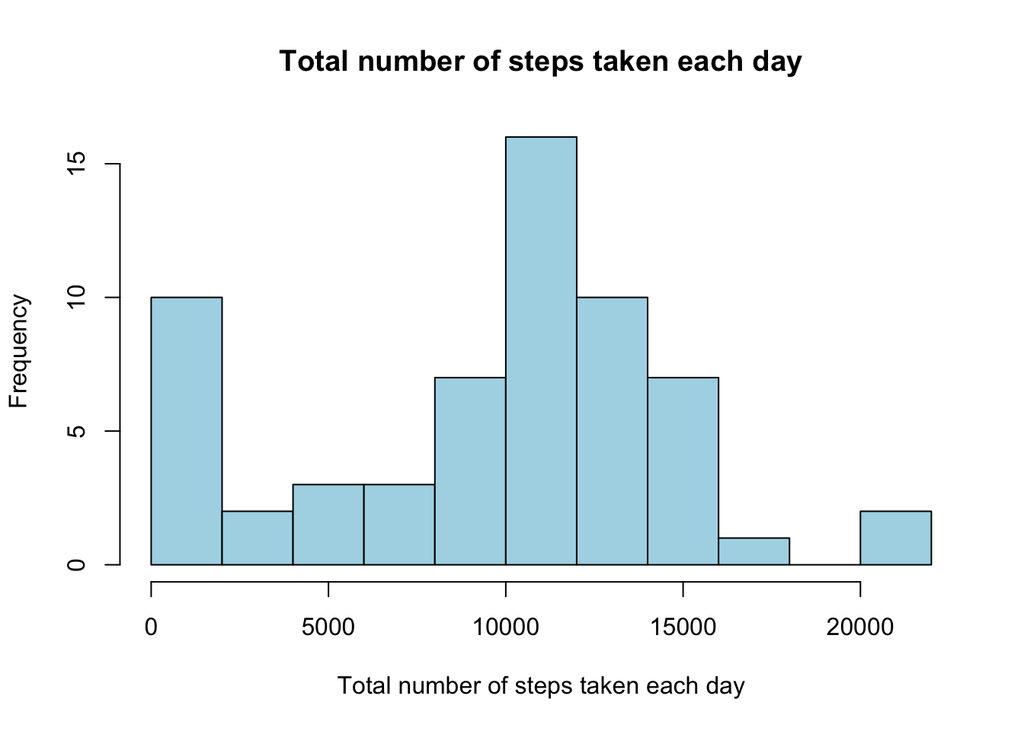

```r
hist(activity_date$steps, breaks=15, col="lightblue", xlab="Total number of steps taken each day", main="Total number of steps taken each day")
```

```r
#ndStep <- tapply(activity$steps, activity$date, function(x) sum(x, na.rm = TRUE))
#hist(ndStep, breaks = 15, col="lightblue", main="Daily Number of Steps",  xlab="Steps")
```

```
1+1
```

3. Calculate the mean and median of the total number of steps taken per day

```r
mean = mean(activity_date$steps)
median = median(activity_date$steps)
```

The mean and median are 9354.2295082 and 10395, respectively.

## What is the average daily activity pattern

1. Make a time series plot (i.e. type = “l”) of the 5-minute interval (x-axis) and the average number of steps taken, averaged across all days (y-axis)

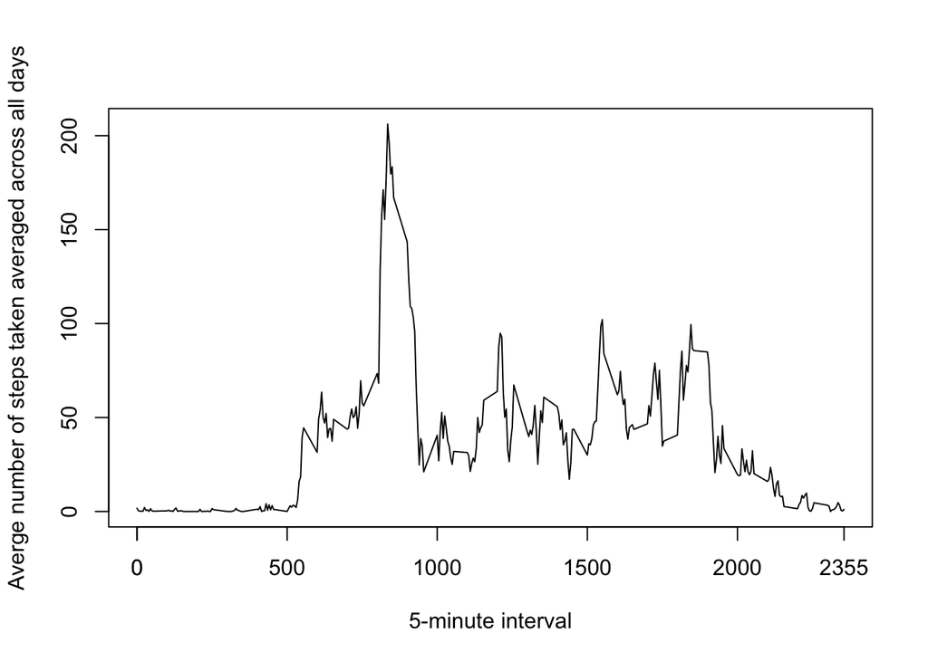

```r
activity_interval   <- group_by(activity, interval)
activity_interval   <- summarise(activity_interval,steps=mean(steps,na.rm=TRUE))
plot(activity_interval$interval, activity_interval$steps, xlab="5-minute interval", ylab="Averge number of steps taken averaged across all days", main=" ", type="l")
## Set the x-axis coordinates to the range (0, 2355)
axis(1, xaxp = c(0, 2355, 1), las = 1)
```

2. Which 5-minute interval, on average across all the days in the dataset, contains the maximum number of steps?

```r
max_index = which.max(activity_interval$steps)
max_int   = activity_interval[max_index,]$interval
```

The 104 5-minute interval or during the time span of 8:35 AM - 8:40 AM, on average across all the days in the dataset, contains the maximum number of steps.

## Imputing missing values

1. Calculate and report the total number of missing values in the dataset (i.e. the total number of rows with NAs)

```r
#totalNumberMissingValues <- count(filter(actDataTable, is.na(steps)))
total_nas <- sum(is.na(activity$steps))
```

The total nmber of missing values in the dataset is 2304.

2. filling in all of the missing values in the dataset.

Let’s extract the measurements with “NA” to a sub-dataset. The procedure is to split the dataset to two sub-datasets, with “NA” and without “NA”. The sub-dataset with NAs with be replaced by the “average daily activity pattern” calculated above. For example, the first 5-minute interval with missing values will be replaced by the first 5-minute interval averaged across all days. The new dataset will be created by *rbind* the two sub-datasets.

```r
activity_notnas <- activity[!is.na(activity$steps),]
activity_nas    <- activity[is.na(activity$steps),]

for (rows in 1:nrow(activity_nas)) {
  activity_nas[rows,]$steps=activity_interval[activity_nas[rows,]$interval==activity_interval$interval,]$steps
}
```

3. Create a new dataset that is equal to the original dataset but with the missing data filled in.

```r
activity_all <- rbind(activity_notnas, activity_nas)
```

4. Make a histogram of the total number of steps taken each day and Calculate and report the mean and median total number of steps taken per day. Do these values differ from the estimates from the first part of the assignment? What is the impact of imputing missing data on the estimates of the total daily number of steps?

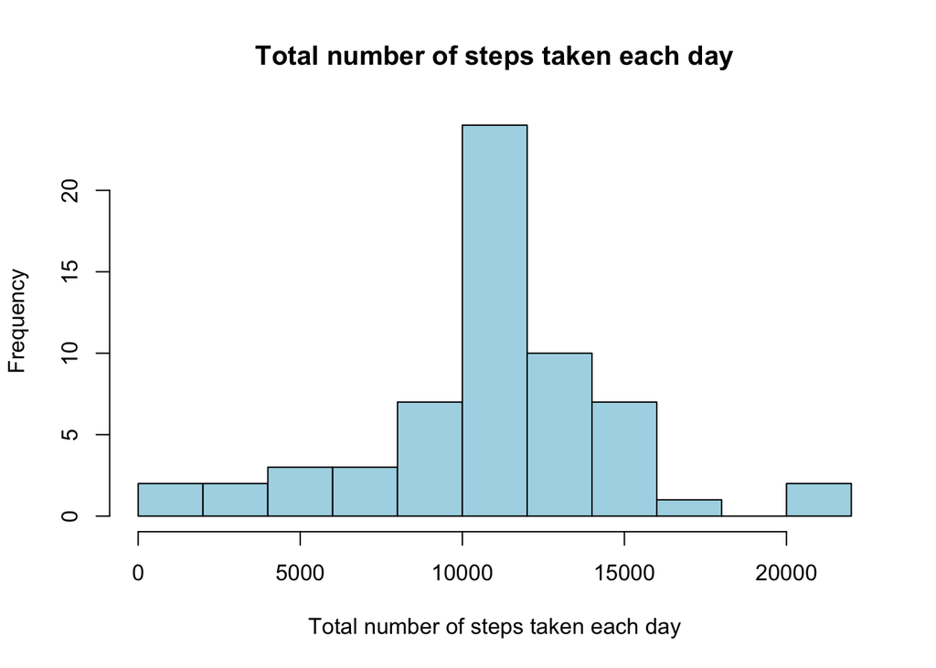

```r
activity_all_date   <- group_by(activity_all, date)
activity_all_date   <- summarise(activity_all_date,steps=sum(steps,na.rm=TRUE))
hist(activity_all_date$steps, breaks = 15, col="lightblue", xlab="Total number of steps taken each day", main="Total number of steps taken each day")
```

```r
mean = mean(activity_all_date$steps)
median = median(activity_all_date$steps)
```

The mean and median are both 10766. They are different from the estimates from the first part of the assignment. The add of the missing data makes the total daily number of steps more like a gaussian distribution which makes lot more sense.

# Are there differences in activity patterns between weekdays and weekends?

1. Create a new factor variable in the dataset with two levels – “weekday” and “weekend” indicating whether a given date is a weekday or weekend day.

```r
activity_all$weekdays <- as.factor(ifelse(weekdays(as.Date(as.character(activity_all$date))) %in% c("Saturday","Sunday"), "Weekend", "Weekday"))
activity_all   <- group_by(activity_all, interval, weekdays)
activity_all   <- summarise(activity_all,steps=sum(steps))
```

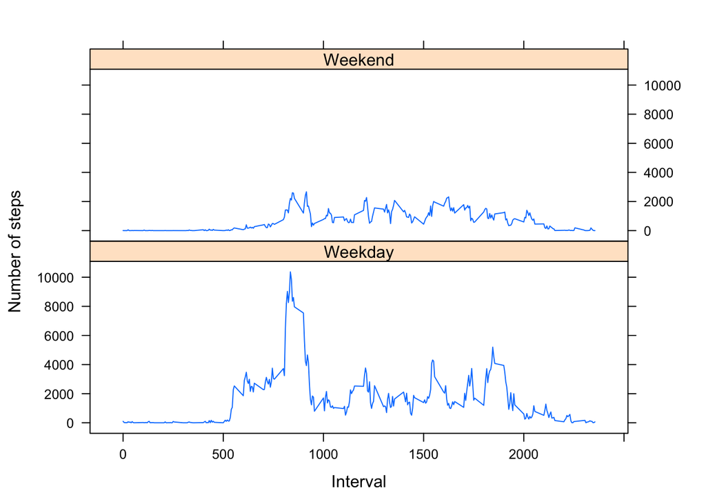

```r
xyplot(steps~interval | weekdays, data=activity_all, type="l", layout=c(1,2), xlab="Interval", ylab="Number of steps", lattice.options=)
```

```r
library(zoo)
```

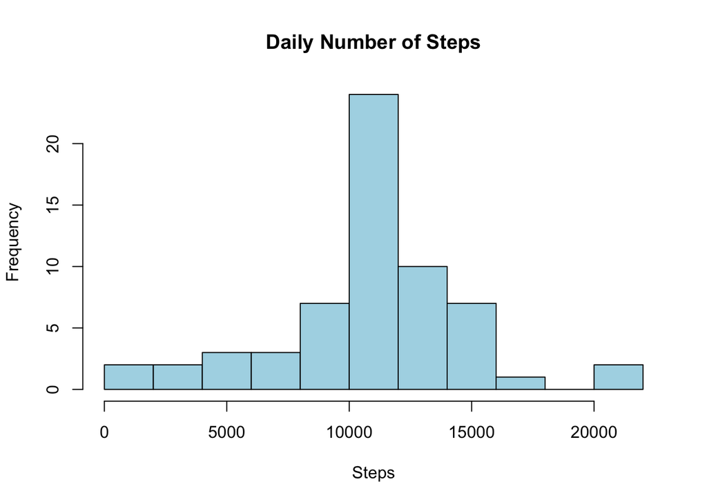

```r
miss <- na.aggregate(activity$steps)
activity -> activitynomiss
activitynomiss$steps <- miss
missStep <- tapply(activitynomiss$steps, activitynomiss$date, function(x) sum(x, na.rm = TRUE))
hist(missStep, breaks = 15, col="lightblue", main="Daily Number of Steps",  xlab="Steps")
```